# exercise_01

## CS-E4825 - Probabilistic Machine Learning D (spring 2025)

Pekka Marttinen, Negar Safinianaini, Mihriban Kocak, Bo Zheng, Batuhan Avci.

## Exercise 1, due on Friday 17th January at 10:15.

#### Contents

1. Problem 1: Coins
2. Problem 2: False positive paradox
3. Problem 3: Markov blanket definition

**Student's task Score: 2.0 / 2.0 (Top)**

## Problem 1: Coins

There are two bent coins ($c_1$ and $c_2$) with different properties, and your objective is to guess which coin was used (i.e. the value of random variable $C \in \{c_1, c_2\}$), after learning whether the result of the coin toss (i.e. the random variable $X \in \{\mbox{h}, \mbox{t}\}$) was heads or tails.

As prior knowledge, we know the probability of each coin resulting in tails: $p(X=\mbox{t} \mid C=c_1) = \theta_1$ and $p(X=\mbox{t} \mid C=c_2) = \theta_2$. In addition, the prior probability for using coin $c_1$ is known: $p(C=c_1) = \pi_1$.

Give the posterior probability of coin $c_1$ being used for the toss, $p(C=c_1 \mid X)$, in terms of $\theta_1$, $\theta_2$ and $\pi_1$, for both $X=\mbox{t}$ and $X=\mbox{h}$.

Furthermore, plot the posterior probability of coin $c_1$, $p(C=c_1 \mid X=\mbox{t})$, as a function of $\theta_1$, when we have $\theta_2 = 0.5$ and $\pi_1 = 0.5$.

Write your solutions in LateX or attach a picture in the answer cell provided below. You can add a picture using the command `!(imagename_in_the_folder.jpg)`. Latex in here works similarly as you would write it normally! You can use some of the definitions from the exercise description as a reference. The list of valid Latex commands in Jypyter notebook can be found here: http://www.onemathematicalcat.org/MathJaxDocumentation/TeXSyntax.htm

=== BEGIN MARK SCHEME ===

### Solution

The posterior probability follows from Bayes' theorem, \begin{equation*} p(A \mid B) = \frac{p(B \mid A) p(A)}{p(B)}, \end{equation*} and the principle of marginalization, \begin{equation*} p(A) = \sum_b p(A,B=b) = \sum_b p(A \mid B=b) p(B=b). \end{equation*} Applying Bayes' theorem in \eqref{eq:bayes} and marginalization in \eqref{eq:marg}, we get the following solution for $p(C=c_1 \mid X=\mbox{t})$: \begin{align} p(C=c_1 \mid X=\mbox{t}) &= \frac{p(X=\mbox{t} \mid C=c_1) p(C=c_1)}{p(X=\mbox{t})} \label{eq:bayes}\tag{1.1} \\ &= \frac{p(X=\mbox{t} \mid C=c_1) p(C=c_1)}{\sum_{i=1}^2 p(X=\mbox{t} \mid C=c_i) p(C=c_i)} \label{eq:marg}\tag{1.2} \\ &= \frac{\theta_1 \pi_1}{\theta_1 \pi_1 + \theta_2 (1-\pi_1)}\nonumber. \end{align} Similarly, for the $X=\mbox{h}$ case: \begin{align*} p(C=c_1 \mid X=\mbox{h}) &= \frac{(1-\theta_1)\pi_1}{(1-\theta_1)\pi_1 + (1-\theta_2)(1-\pi_1)}. \end{align*}

=== END MARK SCHEME ===

$ \textbf{Solution: } \\ p(C = c_1|X) = \frac{p(X|c = c_1) \cdot p(C = c_1)}{p(X)} \\ $

$ p(X) = p(X|C = c_1).p(C = c_1) + p(X|C = c_2).p(C = c_2) \\ => p(X = t) = \theta_1 \cdot \pi_1 + \theta_2 \cdot (1 - \pi_1)\\ $

$ Similarly, \\ p(X = h) = (1 - \theta_1) \cdot \pi_1 + (1- \theta_2) \cdot (1 - \pi_1)\\ $

$ \textbf{(a): } \\ p(C = c_1|X = t) = \frac{p(X = t| C = c_1).p(C = c_1)}{p(X = t)} \\ $ $$ p(C = c_1 \mid X = t) = \frac{\theta_1 \cdot \pi_1}{\theta_1 \cdot \pi_1 + \theta_2 \cdot (1 - \pi_1)} $$

$ \textbf{(b): } \\ p(C = c_1|X = h) = \frac{p(X = h| C = c_1).p(C = c_1)}{p(X=h)} \\ $ $$ p(C = c_1 \mid X = h) = \frac{(1 - \theta_1) \cdot \pi_1}{(1 - \theta_1) \cdot \pi_1 + (1 - \theta_2) \cdot (1 - \pi_1)} $$

**Student's answer(Top)**

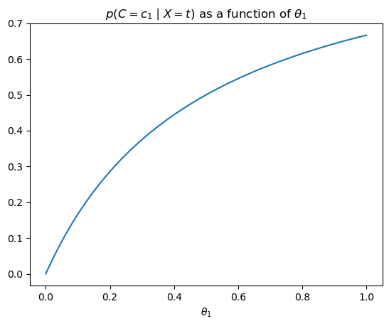

```python
import matplotlib.pyplot as plt
import numpy as np

# define some variables:
theta_2 = 0.5
pi_1 = 0.5

# compute posterior probability of c_1
#theta_1 = ... # choose a reasonable range
#post_c1 = ... # posterior
# YOUR CODE HERE
theta_1 = np.linspace(0,1, 100) # choose a reasonable range
post_c1 = (theta_1*pi_1)/(theta_1*pi_1 + theta_2*(1-pi_1)) # posterior

# plot the result
plt.plot(theta_1, post_c1)
plt.title('$p(C = c_1 \\mid X = t)$ as a function of $\\theta_1$')
plt.xlabel('$\\theta_1$')
plt.show()
```

**Student's task Score: 2.0 / 2.0 (Top)**

## Problem 2: False positive paradox

Consider a hypothetical lie detector that is ''fairly reliable'', in the sense that it will correctly detect 98% of all lies, and also classify as true 98% of all statements that are actually true. This lie detector is being used in an attempt to detect academic dishonesty, by asking ''did you cheat?'' from all students participating in an exam of a machine learning course. (This example is still hypothetical.)

For the purposes of this question, assume as prior knowledge that there are 300 students taking the exam, and a single student has chosen to cheat. We will further assume that all students deny having cheated. If the detector now flags a particular student X as a cheater, how likely is it that X has, in fact, cheated in the exam?

Write your solutions in LateX or attach a picture in the answer cell provided below.

=== BEGIN MARK SCHEME ===

### Solution

Let us denote by $X$ whether the student cheated or not ($X \in \{\text{cheater},\text{honest}\}$), and by $D$ the lie detector report ($D \in \{\text{lie},\text{truth}\}$).

We have the following prior knowledge: \begin{align*} p(X=\text{cheater}) &= \frac{1}{300}\;, \\ p(X=\text{honest}) &= \frac{299}{300}\;, \\ p(D=\text{lie} \mid X=\text{cheater}) &= \frac{98}{100}\;, \\ p(D=\text{lie} \mid X=\text{honest}) &= 1 - p(D=\text{truth} \mid X=\text{honest}) \\ &= 1-\frac{98}{100} = \frac{2}{100}\;, \\ p(D=\text{lie}) &= \sum_X p(D=\text{lie} \mid X) p(X)\;, \\ &= \frac{98}{100} \frac{1}{300} + \frac{2}{100} \frac{299}{300} = \frac{696}{30000}\;. \end{align*}

Applying Bayes' theorem again, \begin{align*} p(X=\text{cheater} \mid D=\text{lie}) &= \frac{p(D=\text{lie} \mid X=\text{cheater}) p(X=\text{cheater})}{p(D=\text{lie})} \\ &= \frac{\frac{98}{100} \frac{1}{300}}{\frac{696}{30000}} = \frac{98}{696} \approx 0.14. \end{align*}

In other words, despite having a ''98% reliable'' detector, if cheating is sufficiently rare, it is far more likely that a student flagged as a liar by the detector is telling the truth than lying.

=== END MARK SCHEME ===

YOUR ANSWER HERE $ \text{Note - Cheated (C), Not Cheated (NC)} \in Students(X) \\ \text{Detected Cheater (DC), Not Detected Cheater (NDC)} \in \text{Lie Detector output (L)} \\ \textbf{Given: } \\ \\ \textbf{True Positive rate: } \\ P(L = DC | X = C) = 0.98 \\ \textbf{False Positive rate: } \\ P(L = DC | X = NC) = 0.02 \\ \textbf{True Negative rate: } \\ P(L = NDC | X = NC) = 0.98 \\ \textbf{False Negative rate: } \\ P(L = NDC | X = C) = 0.02 \\ $

$ \\ \textbf{To find: } \\ $ $$ P(X = C|L = DC) = ? $$

$ \textbf{Solution: } \\ P(X = C|L = DC) = \frac{P(L = DC|X = C).P(X = C)}{P(L = DC)} \\ => P(X = C|L = DC) = \frac{P(L = DC|X = C).P(X = C)}{P(L = DC|X = C).P(X = C) + P(L = DC|X = NC).P(X = NC)} \\ => P(X = C|L = DC) = \frac{0.98*(\frac{1}{300})}{0.98*(\frac{1}{300}) + 0.02*(\frac{299}{300})} \\ => P(X = C|L = DC) = 0.14 \\ i.e. \textbf{there is a 14% probability that X has cheated in the exam when the detector flags a student as a cheater} $

**Student's task Score: 2.0 / 2.0 (Top)**

## Problem 3: Markov blanket definition

Consider the Bayesian network in below. What is the Markov blanket of each variable? (see Barber: [Bayesian Reasoning and Machine Learning](http://web4.cs.ucl.ac.uk/staff/D.Barber/pmwiki/pmwiki.php?n=Brml.Online), ch. 2.1, Definition 2.5)

[figure not shown]

Define Markov blanket for each variable $A,B,C,D,E,F$. You answer should list the nodes that form the Markov blanket for each node. For example, for node A, your answer should look like so $A = \{B, C, D, F\}$

YOUR ANSWER HERE

$B = \{A, C, D, E, F \}$ #EXERCISE

$C = \{A, B, D \}$ #EXERCISE

$D = \{A, B, C, E, F \}$ #EXERCISE

$E = \{B, D, F \}$ #EXERCISE

$F = \{A,B,D, E \}$ #EXERCISE